# Let’s Make A Deal

Antoine, Emmanuel, Syrine

4/9/2020

## Introduction

Our project is based on a TV Show Game. The rules go by this, 3 boxes, inside one of them a million dollar. Inside the other only a dime. The player has to choose a box then the presentator will open a ‘loosing’ box. Will the player stay on his first choice ? Will he change boxes ? We’ll try to compute the best strategy. First we had to code 3 strategies : Keep, Change, Random.

```r
#Function that simulate a game with the changing strategy
change <- function(nb_box = 3) {
  box <- c(1,rep(0,nb_box-1))
  choice <- sample(1:nb_box,1)
  if (choice == 1) {
    box[2] #all the others boxes have the same content
  } else { #If the first choice was wrong only two boxes will remain and he will change
    box[1]
  }
}


keep <- function(nb_box = 3) {
  box <- c(1,rep(0,nb_box-1))
  choice <- sample(1:nb_box,1) #the player will keep his first box no matter what
  box[choice]
}

#In this function, no argument needed because it wont change anything
random <- function() {
  box <- c(1,0)
  choice <- sample(1:2,1) #Very simplified, at the end the player will have the choice between a wrong one and the right one
  box[choice]
}
```

## Results

To see which strategy works the best, we had to stock the score obtained for each game played considering the strategy. This allowed us to obtain 3 vectors : resultChange, resultKeep and resultRandom. By computing the mean of theses vectors we’ll obtain the average money won for each strategy

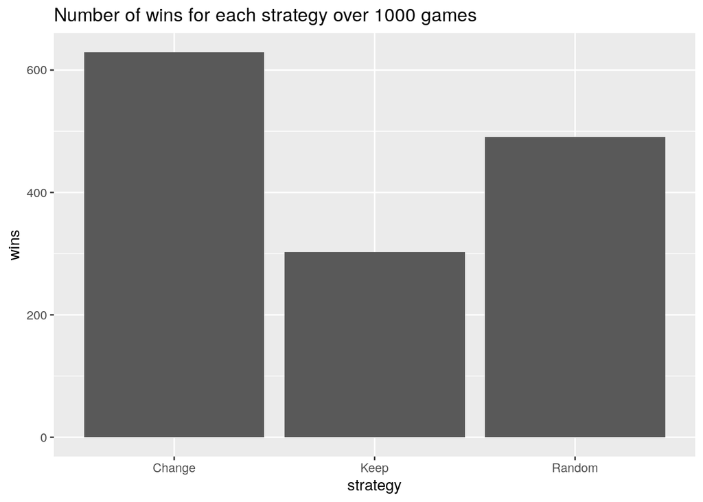

## Variation

We can wonder what happends if we play not with 3 boxes but with 100. The rules change a bit, now the player chooses one box then the presentator open 98 others, leaving to the player the choice to either keep its first box or to choose the one that the presentator didn’t opened.

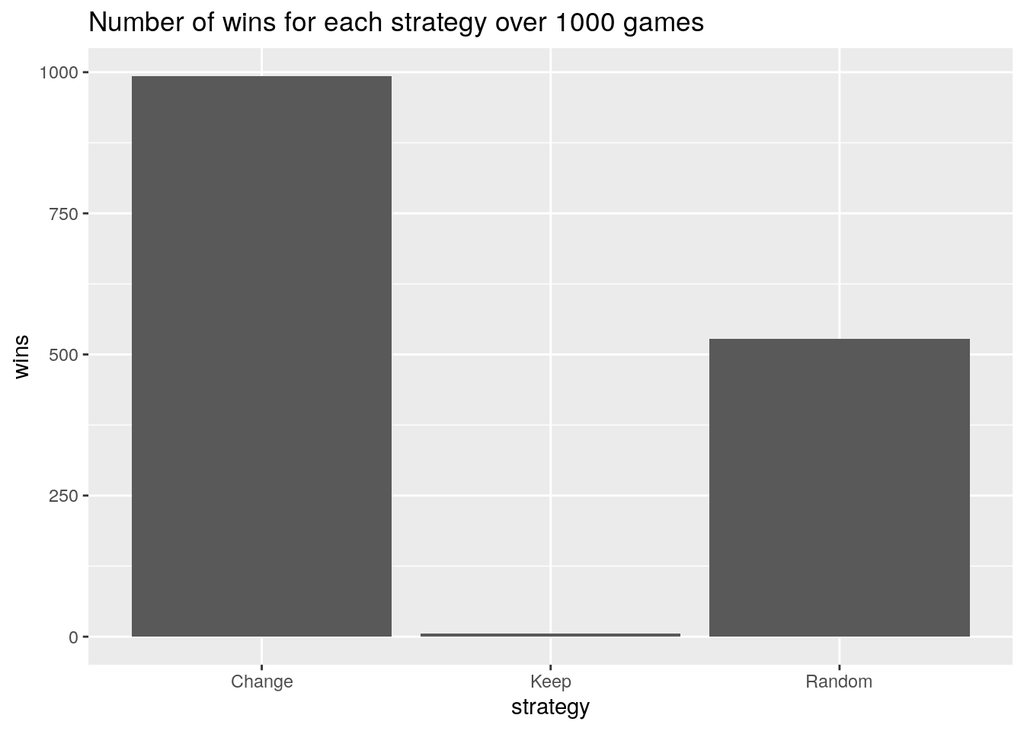

## Interpretation

As we could expect, the changing strategy works better with a consequent number of box. Because the chance to get the winning box on the first try is low (1/100 here).